# Exam 1

## Exam 1

#### Metainformation

1. | Tag | Value |
   | --- | --- |
   | `file` | Inferential_Statistics_vufsw-oneway_anova-1321-nl_vufsw-oneway_anova-1321-nl |
   | `name` | vufsw-oneway anova-1321-nl |
   | `section` | inferential statistics/parametric techniques/anova/oneway anova |
   | `type` | schoice |
   | `solution` | FALSE, TRUE, FALSE, FALSE |
   | `ID` | a405d |
   | `Type` | interpreting output |
   | `Program` | NA |
   | `Language` | Dutch |
   | `Level` | statistical thinking |

#### Question

   Onderstaande analyses zijn afkomstig van een representatieve steekproef uit de Nederlandse bevolking (ISSP, 2007). De vraag is of de ‘happiness’ (variabele happy: schaal 1-4, een hogere score betekent dat men in het algemeen vaker gelukkig is) verschilt tussen niet-religieuze personen en religieuze personen met verschillende religies.

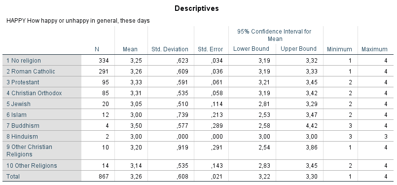

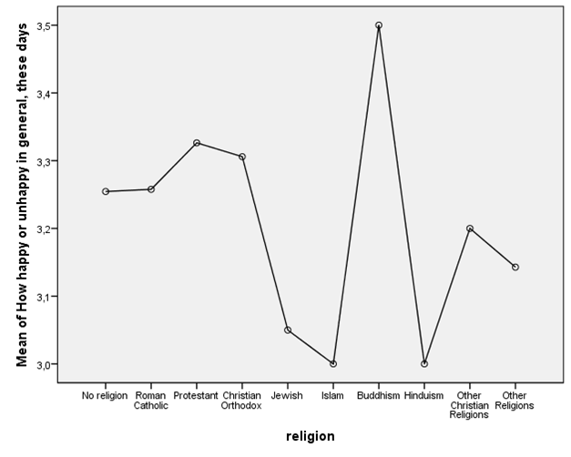

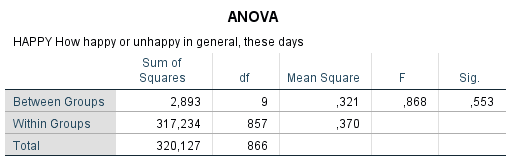

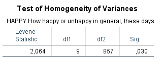

   Hoe kunnen we de uitkomsten van de analyse samenvatten?
   1. **FALSE:** De F-toets wijst uit dat het aannemelijk is dat de gemiddelde ‘happiness’ in de groepen niet gelijk is in de populatie, maar er is niet aan de assumptie van homogeniteit van varianties voldaan, dus kunnen we geen definitieve uitspraken doen
   2. **TRUE:** De F-toets wijst uit dat er onvoldoende bewijs is dat de gemiddelde ‘happiness’ in de groepen niet gelijk is in de populatie, maar er is niet aan de assumptie van homogeniteit van varianties voldaan, dus kunnen we geen definitieve uitspraken doen
   3. **FALSE:** De F-toets wijst uit dat het aannemelijk is dat de gemiddelde ‘happiness’ in de groepen niet hetzelfde is in de populatie. Omdat er aan de assumptie van homogeniteit van varianties is voldaan, is dit de samenvatting van de uitkomsten.
   4. **FALSE:** De F-toets wijst uit dat er onvoldoende bewijs is dat de gemiddelde ‘happiness’ in de groepen niet gelijk is in de populatie. Omdat er aan de assumptie van homogeniteit van varianties is voldaan, is dit de samenvatting van de uitkomsten.
   1. False
   2. True
   3. False
   4. False